# Análisis sobre reports de Nessus

#### Marc Astals, Eloi Manuel, Miquel Pérez, Daniel Salmerón

## Introducción

En este documento se muestran un conjunto de métricas extraidas a partid de un report de Nessus en formato .nessus *([Nessus V2 File Format](http://static.tenable.com/documentation/nessus_v2_file_format.pdf))*.  
[Nessus](http://www.tenable.com/products/nessus-vulnerability-scanner) es un programa de escaneo de vulnerabilidades desarrollado por [Tenable Network Security](http://www.tenable.com/) y actualmente se ha convertido en uno de los mas potentes y mas usados por los analistas de seguridad y administradores de sistemas.

## Métricas

### Como de criticas son las vulnerabilidades de nuestro sistema?

El siguiente gráfico y sus detalles muestran como se distribuyen las vulnerabilidades de nuestro sistema según su [CVSS](https://www.first.org/cvss).

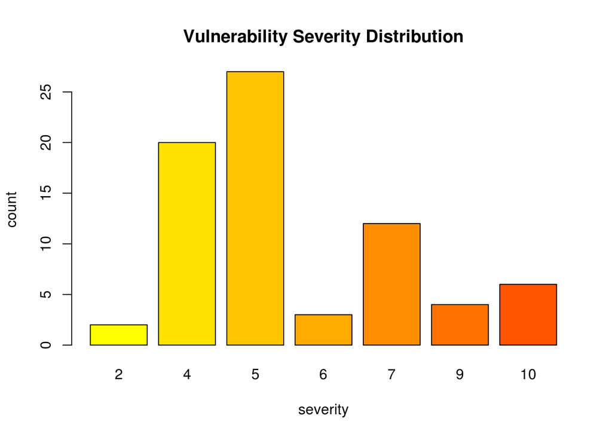

```
##  2  4  5  6  7  9 10
##  2 20 27  3 12  4  6
```

El siguiente gráfico y sus detalles muestran como se distribuyen las vulnerabilidades de nuestro sistema según la clasificación de Nessus.

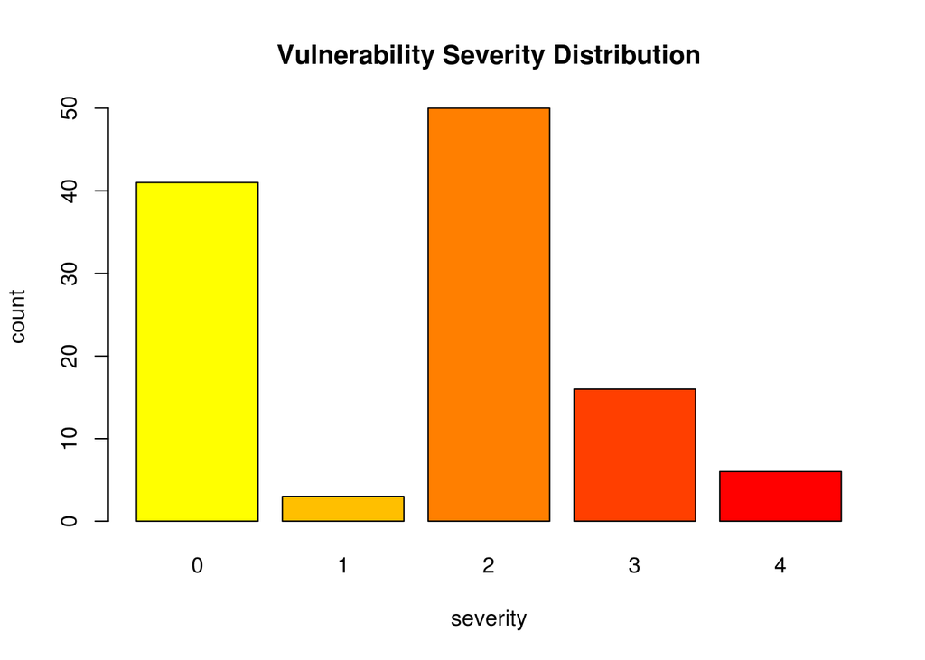

```
##  0  1  2  3  4
## 41  3 50 16  6
```

### Que maquinas tienen un mayor numero de vulnerabilidades?

El siguiente gráfico y sus detalles muestran cuales de nuestras maquinas son las que recogen un mayor numero de vulnerabilidades.

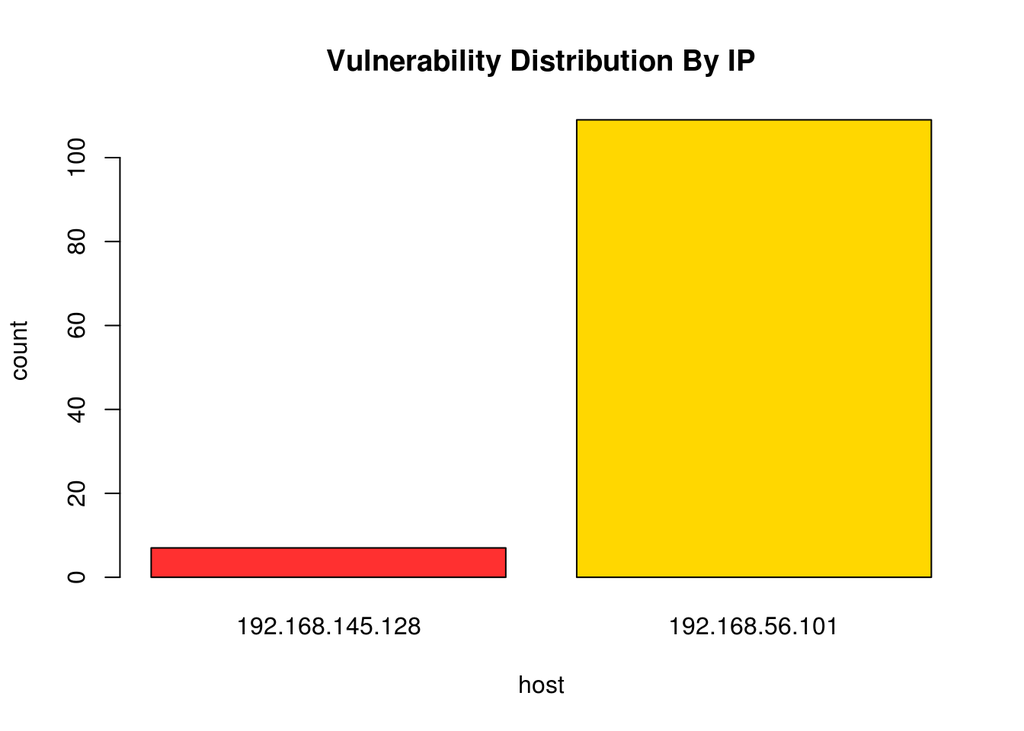

```
## 192.168.145.128  192.168.56.101
##               7             109
```

### Sobre que puertos tenemos un mayor numero de vulnerabilidades?

El siguiente gráfico y sus detalles muestran la afectación de las vulnerabilidades de nuestro sistema según su puerto.

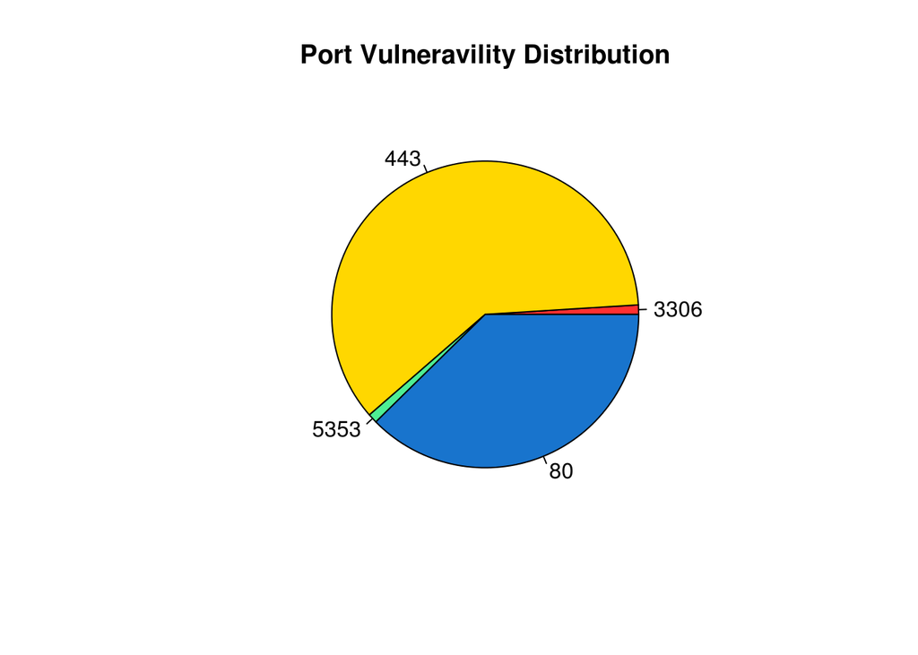

```
## 3306  443 5353   80
##    1   61    1   38
```

### Cuales son nuestras vulnerabilidades?

El siguiente gráfico y sus detalles muestra la afectación de las vulnerabilidades de nuestro sistema según su [CVE](https://cve.mitre.org/).

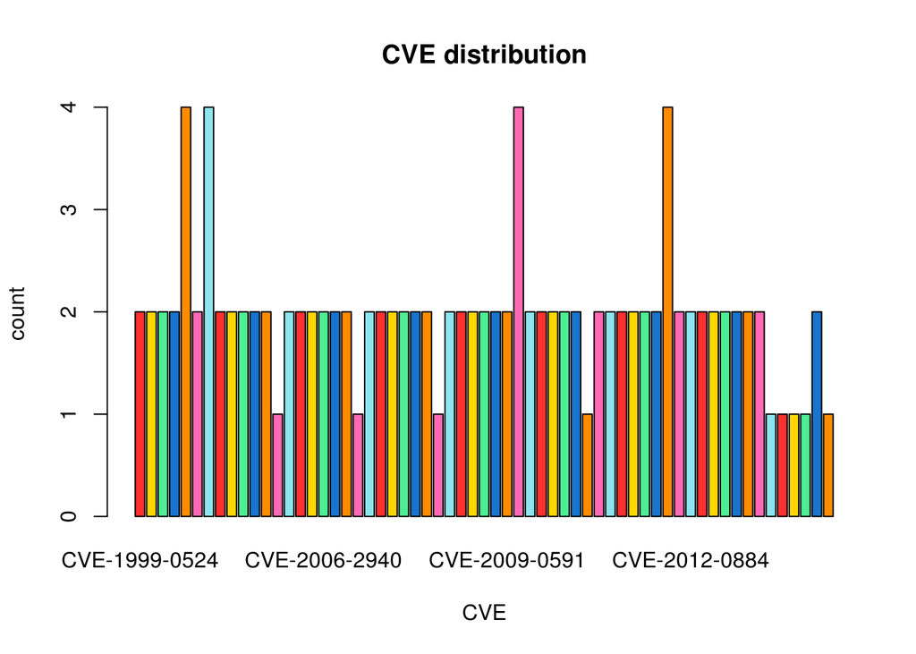

```
## CVE-1999-0524 CVE-2003-0542 CVE-2003-1418 CVE-2003-1567 CVE-2004-0079
##             2             2             2             2             4
## CVE-2004-0081 CVE-2004-0112 CVE-2004-0488 CVE-2004-0492 CVE-2004-0700
##             2             4             2             2             2
## CVE-2004-0975 CVE-2004-2320 CVE-2004-2761 CVE-2005-2946 CVE-2005-2969
##             2             2             1             2             2
## CVE-2006-2937 CVE-2006-2940 CVE-2006-3738 CVE-2006-3747 CVE-2006-3918
##             2             2             2             2             1
## CVE-2006-4339 CVE-2006-4343 CVE-2006-7250 CVE-2007-3108 CVE-2007-4995
##             2             2             2             2             2
## CVE-2007-5135 CVE-2007-5944 CVE-2008-0891 CVE-2008-1672 CVE-2008-2168
##             2             1             2             2             2
## CVE-2008-5077 CVE-2009-0590 CVE-2009-0591 CVE-2009-0789 CVE-2009-1377
##             2             2             2             4             2
## CVE-2009-1378 CVE-2009-1386 CVE-2009-2409 CVE-2010-0386 CVE-2010-4180
##             2             2             2             2             1
## CVE-2011-1945 CVE-2011-4108 CVE-2011-4109 CVE-2011-4354 CVE-2011-4576
##             2             2             2             2             2
## CVE-2011-4577 CVE-2011-4619 CVE-2012-0053 CVE-2012-0884 CVE-2012-1165
##             2             4             2             2             2
## CVE-2012-2110 CVE-2012-2131 CVE-2012-2333 CVE-2013-0166 CVE-2013-0169
##             2             2             2             2             2
## CVE-2013-2566 CVE-2014-3566 CVE-2015-0204 CVE-2015-2808 CVE-2015-4000
##             1             1             1             1             2
## CVE-2016-0800
##             1
```

### Sobre que debilidades se encuentran nuestras vulnerabilidades?

El siguiente gráfico y sus detalles muestra la afectación de las vulnerabilidades de nuestro sistema según su [CWE](https://cwe.mitre.org/).

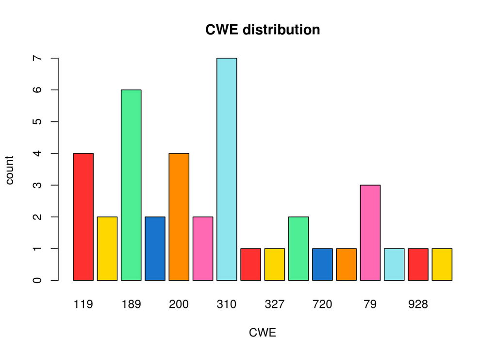

```
## 119  16 189  20 200 287 310 326 327 399 720 753  79 803 928 934
##   4   2   6   2   4   2   7   1   1   2   1   1   3   1   1   1
```